# Marketing_BtoC1

**Made By DAHOU RENAUD L. Data Scientist in Benin**

- Whatsapp: +22967927952
- Email: dahou.r@yahoo.com

## **Répertoire de travail**

```python
from google.colab import drive
drive.mount('/content/drive/')
```

```python
import os
os.chdir("/content/drive/My Drive/DATASCIENCE/Projet/Segmentation_de_client")
```

## **Importation des librairies python**

```python
!jupyter nbconvert --to html Marketing_BtoC1.ipynb
```

```
[NbConvertApp] Converting notebook Marketing_BtoC1.ipynb to html
[NbConvertApp] Writing 2057338 bytes to Marketing_BtoC1.html
```

```python
import numpy as np
import pandas as pd
import matplotlib.pyplot as plt
import seaborn as sns
sns.set()

import datetime as dt
from datetime import datetime, timedelta,date

from sklearn.cluster import KMeans
from sklearn.svm import SVC
from sklearn.multioutput import MultiOutputClassifier
from sklearn.ensemble import GradientBoostingClassifier
from sklearn.tree import DecisionTreeClassifier
from sklearn.neighbors import KNeighborsClassifier
from sklearn.naive_bayes import GaussianNB
from sklearn.ensemble import RandomForestClassifier
from sklearn.linear_model import LogisticRegression
import xgboost as xgb

from sklearn.model_selection import KFold, cross_val_score, train_test_split
from sklearn.metrics import classification_report,confusion_matrix
from sklearn.model_selection import GridSearchCV

from sklearn.metrics import r2_score, median_absolute_error, mean_absolute_error
from sklearn.metrics import median_absolute_error, mean_squared_error, mean_squared_log_error

from scipy.optimize import minimize
import statsmodels.tsa.api as smt
import statsmodels.api as sm

from tqdm import tqdm_notebook

from itertools import product

def mean_absolute_percentage_error(y_true, y_pred):
    return np.mean(np.abs((y_true - y_pred) / y_true)) * 100

import warnings
warnings.filterwarnings('ignore')

%matplotlib inline
```

# **EDA Segmentation de client e-commerce; prédiction du CLV(la valeur à vie du client) ;prédiction du prochain jour d'achat et prevision des ventes**

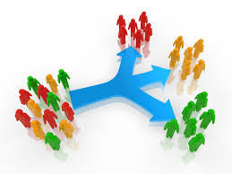

[figure not shown]

pour déterminer qui sont nos meilleurs clients, l’ancien principe de matrice RFM est le meilleur. RFM signifie Recency, Frequency, and Monetary. Il s'agit d'une technique de segmentation de la clientèle qui utilise le comportement d'achat passé pour diviser les clients en groupes

### **Chargement de la base de donnée**

```python
# download dataset
#! wget https://archive.ics.uci.edu/ml/machine-learning-databases/00352/Online%20Retail.xlsx -P "/content/drive/My Drive/DATASCIENCE/Projet/prédiction_de_prix_des_maison"
```

```python
#load dataset
df = pd.read_excel("Online Retail.xlsx")
df
```

|  | InvoiceNo | StockCode | Description | Quantity | InvoiceDate | UnitPrice | CustomerID | Country |
| --- | --- | --- | --- | --- | --- | --- | --- | --- |
| 0 | 536365 | 85123A | WHITE HANGING HEART T-LIGHT HOLDER | 6 | 2010-12-01 08:26:00 | 2.55 | 17850.0 | United Kingdom |
| 1 | 536365 | 71053 | WHITE METAL LANTERN | 6 | 2010-12-01 08:26:00 | 3.39 | 17850.0 | United Kingdom |
| 2 | 536365 | 84406B | CREAM CUPID HEARTS COAT HANGER | 8 | 2010-12-01 08:26:00 | 2.75 | 17850.0 | United Kingdom |
| 3 | 536365 | 84029G | KNITTED UNION FLAG HOT WATER BOTTLE | 6 | 2010-12-01 08:26:00 | 3.39 | 17850.0 | United Kingdom |
| 4 | 536365 | 84029E | RED WOOLLY HOTTIE WHITE HEART. | 6 | 2010-12-01 08:26:00 | 3.39 | 17850.0 | United Kingdom |
| ... | ... | ... | ... | ... | ... | ... | ... | ... |
| 541904 | 581587 | 22613 | PACK OF 20 SPACEBOY NAPKINS | 12 | 2011-12-09 12:50:00 | 0.85 | 12680.0 | France |
| 541905 | 581587 | 22899 | CHILDREN'S APRON DOLLY GIRL | 6 | 2011-12-09 12:50:00 | 2.10 | 12680.0 | France |
| 541906 | 581587 | 23254 | CHILDRENS CUTLERY DOLLY GIRL | 4 | 2011-12-09 12:50:00 | 4.15 | 12680.0 | France |
| 541907 | 581587 | 23255 | CHILDRENS CUTLERY CIRCUS PARADE | 4 | 2011-12-09 12:50:00 | 4.15 | 12680.0 | France |
| 541908 | 581587 | 22138 | BAKING SET 9 PIECE RETROSPOT | 3 | 2011-12-09 12:50:00 | 4.95 | 12680.0 | France |

541909 rows × 8 columns

```python
df1 = df
df1.head()
```

|  | InvoiceNo | StockCode | Description | Quantity | InvoiceDate | UnitPrice | CustomerID | Country |
| --- | --- | --- | --- | --- | --- | --- | --- | --- |
| 0 | 536365 | 85123A | WHITE HANGING HEART T-LIGHT HOLDER | 6 | 2010-12-01 08:26:00 | 2.55 | 17850.0 | United Kingdom |
| 1 | 536365 | 71053 | WHITE METAL LANTERN | 6 | 2010-12-01 08:26:00 | 3.39 | 17850.0 | United Kingdom |
| 2 | 536365 | 84406B | CREAM CUPID HEARTS COAT HANGER | 8 | 2010-12-01 08:26:00 | 2.75 | 17850.0 | United Kingdom |
| 3 | 536365 | 84029G | KNITTED UNION FLAG HOT WATER BOTTLE | 6 | 2010-12-01 08:26:00 | 3.39 | 17850.0 | United Kingdom |
| 4 | 536365 | 84029E | RED WOOLLY HOTTIE WHITE HEART. | 6 | 2010-12-01 08:26:00 | 3.39 | 17850.0 | United Kingdom |

L'ensemble de données contient toutes les transactions entre le 01/12/2010 et le 09/12/2011 pour un détaillant en ligne basé au Royaume-Uni et enregistré.

Explorez les données - validation et nouvelles variables

1. Valeurs manquantes dans les colonnes importantes;
2. distribution des clients dans chaque pays;
3. Le prix unitaire et la quantité doivent être> 0;
4. La date de facturation devrait <aujourd'hui.

```python
#Il y avait 38 pays uniques comme suit:
df1.Country.unique()
```

```
array(['United Kingdom', 'France', 'Australia', 'Netherlands', 'Germany',
       'Norway', 'EIRE', 'Switzerland', 'Spain', 'Poland', 'Portugal',
       'Italy', 'Belgium', 'Lithuania', 'Japan', 'Iceland',
       'Channel Islands', 'Denmark', 'Cyprus', 'Sweden', 'Austria',
       'Israel', 'Finland', 'Bahrain', 'Greece', 'Hong Kong', 'Singapore',
       'Lebanon', 'United Arab Emirates', 'Saudi Arabia',
       'Czech Republic', 'Canada', 'Unspecified', 'Brazil', 'USA',
       'European Community', 'Malta', 'RSA'], dtype=object)
```

```python
customer_country=df1[['Country','CustomerID']].drop_duplicates()
customer_country.groupby(['Country'])['CustomerID'].aggregate('count').reset_index().sort_values('CustomerID', ascending=False)
```

|  | Country | CustomerID |
| --- | --- | --- |
| 36 | United Kingdom | 3950 |
| 14 | Germany | 95 |
| 13 | France | 87 |
| 31 | Spain | 31 |
| 3 | Belgium | 25 |
| 33 | Switzerland | 21 |
| 27 | Portugal | 19 |
| 19 | Italy | 15 |
| 12 | Finland | 12 |
| 1 | Austria | 11 |
| 25 | Norway | 10 |
| 24 | Netherlands | 9 |
| 0 | Australia | 9 |
| 6 | Channel Islands | 9 |
| 9 | Denmark | 9 |
| 7 | Cyprus | 8 |
| 32 | Sweden | 8 |
| 20 | Japan | 8 |
| 26 | Poland | 6 |
| 34 | USA | 4 |
| 5 | Canada | 4 |
| 37 | Unspecified | 4 |
| 18 | Israel | 4 |
| 15 | Greece | 4 |
| 10 | EIRE | 3 |
| 23 | Malta | 2 |
| 35 | United Arab Emirates | 2 |
| 2 | Bahrain | 2 |
| 22 | Lithuania | 1 |
| 8 | Czech Republic | 1 |
| 21 | Lebanon | 1 |
| 28 | RSA | 1 |
| 29 | Saudi Arabia | 1 |
| 30 | Singapore | 1 |
| 17 | Iceland | 1 |
| 4 | Brazil | 1 |
| 11 | European Community | 1 |
| 16 | Hong Kong | 0 |

Plus de 90% des clients dans les données proviennent du Royaume-Uni. Certaines recherches indiquent que les groupes de clients varient selon les régions. Je limiterai donc les données au Royaume-Uni.

```python
df1 = df1.loc[df1['Country'] == 'United Kingdom']

#Vérifions s'il y a des valeurs manquantes dans chaque colonne
df1.isnull().sum(axis=0)
```

```
InvoiceNo           0
StockCode           0
Description      1454
Quantity            0
InvoiceDate         0
UnitPrice           0
CustomerID     133600
Country             0
dtype: int64
```

Il y a 133 600 valeurs manquantes dans la colonne CustomerID et, comme notre analyse est basée sur les clients, nous allons supprimer ces valeurs manquantes.

```python
df1 = df1[pd.notnull(df1['CustomerID'])]
```

```python
#Vérifions les valeurs minimales dans les colonnes UnitPrice et Quantity.
df1.UnitPrice.min()
```

```
0.0
```

```python
df1.Quantity.min()
```

```
-80995
```

```python
#Supprimons les valeurs négatives dans la colonne Quantity.

df1 = df1[(df1['Quantity']>0)]
df1.shape
```

```
(354345, 8)
```

```python
df1.info()
```

```
<class 'pandas.core.frame.DataFrame'>
Int64Index: 354345 entries, 0 to 541893
Data columns (total 8 columns):
InvoiceNo      354345 non-null object
StockCode      354345 non-null object
Description    354345 non-null object
Quantity       354345 non-null int64
InvoiceDate    354345 non-null datetime64[ns]
UnitPrice      354345 non-null float64
CustomerID     354345 non-null float64
Country        354345 non-null object
dtypes: datetime64[ns](1), float64(2), int64(1), object(4)
memory usage: 24.3+ MB
```

```python
#Après avoir nettoyé les données, nous avons maintenant 354345 lignes et 8 colonnes.
#Vérifions la valeur unique pour chaque colonne.

def unique_counts(df1):
   for i in df1.columns:
       count = df1[i].nunique()
       print(i, ": ", count)
unique_counts(df1)
```

```
InvoiceNo :  16649
StockCode :  3645
Description :  3844
Quantity :  294
InvoiceDate :  15615
UnitPrice :  403
CustomerID :  3921
Country :  1
```

```python
# ajoutons une collone TotalPrice
df1['TotalPrice'] = df1['Quantity'] * df1['UnitPrice']
```

```python
#Découvrons les dates de première et dernière commande dans les données.
df1['InvoiceDate'].min()
```

```
Timestamp('2010-12-01 08:26:00')
```

```python
df1['InvoiceDate'].max()
```

```
Timestamp('2011-12-09 12:49:00')
```

Étant donné que la récence (recency) est calculée pour un moment donné et que la dernière date de facturation est 2011-12-09, nous utiliserons 2011-12-10 pour la calculer

```python
NOW = dt.datetime(2011,12,10)
df1['InvoiceDate'] = pd.to_datetime(df1['InvoiceDate'])
```

# **Segmentation client RFM**

La segmentation RFM commence à partir d'ici.

Créons une table RFM et calculons des métriques RFM pour chaque client

```python
rfmTable = df1.groupby('CustomerID').agg({'InvoiceDate': lambda x: (NOW - x.max()).days,
                                        'InvoiceNo': lambda x: len(x),
                                        'TotalPrice': lambda x: x.sum()})

rfmTable['InvoiceDate'] = rfmTable['InvoiceDate'].astype(int)
rfmTable.rename(columns={'InvoiceDate': 'recency',
                         'InvoiceNo': 'frequency',
                         'TotalPrice': 'monetary_value'}, inplace=True)
rfmTable.head()
```

| CustomerID | recency | frequency | monetary_value |
| --- | --- | --- | --- |
| 12346.0 | 325 | 1 | 77183.60 |
| 12747.0 | 2 | 103 | 4196.01 |
| 12748.0 | 0 | 4596 | 33719.73 |
| 12749.0 | 3 | 199 | 4090.88 |
| 12820.0 | 3 | 59 | 942.34 |

### Interprétation:

1. CustomerID 12346 a une fréquence de 1, une valeur monétaire: 77 183,60 $ et une récence: 325 jours.
2. Le numéro d’identité client 12747 a une fréquence de 103, une valeur monétaire de 4 196,01 USD et une récence: 2 jours

```python
#Vérifions les détails du premier client.
first_customer = df1[df1['CustomerID']== 12346.0]
first_customer
```

|  | InvoiceNo | StockCode | Description | Quantity | InvoiceDate | UnitPrice | CustomerID | Country | TotalPrice |
| --- | --- | --- | --- | --- | --- | --- | --- | --- | --- |
| 61619 | 541431 | 23166 | MEDIUM CERAMIC TOP STORAGE JAR | 74215 | 2011-01-18 10:01:00 | 1.04 | 12346.0 | United Kingdom | 77183.6 |

Le premier client n'a acheté qu'une fois, a acheté un produit en grande quantité (74 215). Le prix unitaire est très bas; peut-être une vente de liquidation.

## **Scinder les métriques**

Le moyen le plus simple de scinder les métriques en segments consiste à utiliser des quartiles.

- Cela nous donne un point de départ pour l'analyse détaillée.
- 4 segments sont faciles à comprendre et à expliquer.

```python
quantiles = rfmTable.quantile(q=[0.25,0.5,0.75])
quantiles = quantiles.to_dict()
```

## **Création d' une table RFM segmentée**

```python
segmented_rfm = rfmTable
```

La plus récente récence, la fréquence la plus élevée et les montants monétaires sont nos meilleurs clients.

```python
def RScore(x,p,d):
    if x <= d[p][0.25]:
        return 1
    elif x <= d[p][0.50]:
        return 2
    elif x <= d[p][0.75]:
        return 3
    else:
        return 4

def FMScore(x,p,d):
    if x <= d[p][0.25]:
        return 4
    elif x <= d[p][0.50]:
        return 3
    elif x <= d[p][0.75]:
        return 2
    else:
        return 1
```

```python
#Ajoutons des numéros de segment à la table RFM segmentée nouvellement créée
segmented_rfm['r_quartile'] = segmented_rfm['recency'].apply(RScore, args=('recency',quantiles,))
segmented_rfm['f_quartile'] = segmented_rfm['frequency'].apply(FMScore, args=('frequency',quantiles,))
segmented_rfm['m_quartile'] = segmented_rfm['monetary_value'].apply(FMScore, args=('monetary_value',quantiles,))
segmented_rfm.head()
```

| CustomerID | recency | frequency | monetary_value | r_quartile | f_quartile | m_quartile |
| --- | --- | --- | --- | --- | --- | --- |
| 12346.0 | 325 | 1 | 77183.60 | 4 | 4 | 1 |
| 12747.0 | 2 | 103 | 4196.01 | 1 | 1 | 1 |
| 12748.0 | 0 | 4596 | 33719.73 | 1 | 1 | 1 |
| 12749.0 | 3 | 199 | 4090.88 | 1 | 1 | 1 |
| 12820.0 | 3 | 59 | 942.34 | 1 | 2 | 2 |

Les segments RFM divisent la clientèle en un cube 3D imaginaire difficile à visualiser. Cependant, nous pouvons résoudre ce problème.

### **Ajoutons une nouvelle colonne pour combiner le score RFM: 111 est le score le plus élevé déterminé précédemment**

```python
segmented_rfm['RFMScore'] = segmented_rfm.r_quartile.map(str)+ segmented_rfm.f_quartile.map(str)+ segmented_rfm.m_quartile.map(str)
segmented_rfm['OverallScore'] = segmented_rfm.r_quartile+ segmented_rfm.f_quartile+ segmented_rfm.m_quartile
segmented_rfm.groupby('OverallScore')['recency','frequency','monetary_value'].mean()
segmented_rfm.head()
```

| CustomerID | recency | frequency | monetary_value | r_quartile | f_quartile | m_quartile | RFMScore | OverallScore |
| --- | --- | --- | --- | --- | --- | --- | --- | --- |
| 12346.0 | 325 | 1 | 77183.60 | 4 | 4 | 1 | 441 | 9 |
| 12747.0 | 2 | 103 | 4196.01 | 1 | 1 | 1 | 111 | 3 |
| 12748.0 | 0 | 4596 | 33719.73 | 1 | 1 | 1 | 111 | 3 |
| 12749.0 | 3 | 199 | 4090.88 | 1 | 1 | 1 | 111 | 3 |
| 12820.0 | 3 | 59 | 942.34 | 1 | 2 | 2 | 122 | 5 |

Il est évident que le premier client n'est pas notre meilleur client

**Qui sont le top 10 de nos meilleurs clients!**

```python
segmented_rfm[segmented_rfm['OverallScore']==3].sort_values('monetary_value', ascending=False).head(10)
```

| CustomerID | recency | frequency | monetary_value | r_quartile | f_quartile | m_quartile | RFMScore | OverallScore |
| --- | --- | --- | --- | --- | --- | --- | --- | --- |
| 18102.0 | 0 | 431 | 259657.30 | 1 | 1 | 1 | 111 | 3 |
| 17450.0 | 8 | 337 | 194550.79 | 1 | 1 | 1 | 111 | 3 |
| 17511.0 | 2 | 963 | 91062.38 | 1 | 1 | 1 | 111 | 3 |
| 16684.0 | 4 | 277 | 66653.56 | 1 | 1 | 1 | 111 | 3 |
| 14096.0 | 4 | 5111 | 65164.79 | 1 | 1 | 1 | 111 | 3 |
| 13694.0 | 3 | 568 | 65039.62 | 1 | 1 | 1 | 111 | 3 |
| 15311.0 | 0 | 2379 | 60767.90 | 1 | 1 | 1 | 111 | 3 |
| 13089.0 | 2 | 1818 | 58825.83 | 1 | 1 | 1 | 111 | 3 |
| 15769.0 | 7 | 130 | 56252.72 | 1 | 1 | 1 | 111 | 3 |
| 15061.0 | 3 | 403 | 54534.14 | 1 | 1 | 1 | 111 | 3 |

```python
segmented_rfm['OverallScore'].unique()
```

```
array([ 9,  3,  5, 12,  7,  8,  6, 10, 11,  4])
```

### **Cindage en grappe et Visualisation**

Le score ci-dessus nous montre clairement que les clients avec un score de 3 sont nos meilleurs clients alors que 12 est le pire.

```python
segmented_rfm.groupby('OverallScore')['recency'].count()
```

```
OverallScore
3     409
4     345
5     386
6     380
7     408
8     393
9     425
10    470
11    362
12    343
Name: recency, dtype: int64
```

Pour garder les choses simples, mieux nous nommons ces scores:

- 3 à 5:Haute valeur
- 6 à 8: valeur moyenne
- 9+: faible valeur

Nous pouvons facilement appliquer cette dénomination sur notre base de données:

```python
segmented_rfm['Segment'] = 'Low-Value'
segmented_rfm.loc[segmented_rfm['OverallScore']<9,'Segment'] = 'Mid-Value'
segmented_rfm.loc[segmented_rfm['OverallScore']<6,'Segment'] = 'High-Value'
```

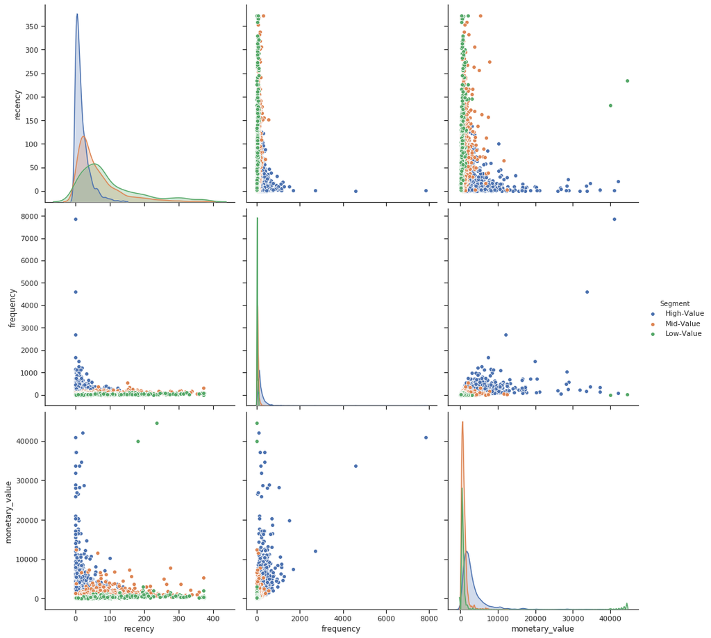

```python
#Figure 1
sns.set(style="ticks")
df_graph = segmented_rfm.query("monetary_value < 50000 and OverallScore < 10")
sns.pairplot(df_graph[['recency','frequency','monetary_value','Segment']], hue="Segment",size=4.5)
plt.savefig("RFM.png")
```

Les Marketers peuvent commencer à prendre des mesures avec cette segmentation. Les principales stratégies sont assez claires:

- Haute Valeur: Améliorer La Rétention
- Valeur Moyenne: Améliorer La Rétention + Augmenter La Fréquence
- Faible Valeur: Augmenter La Fréquence

## **Custumer Lifetime Value(CLV)**

Nous investissons dans les clients (coûts d'acquisition, publicités hors ligne, promotions, remises, etc.) pour générer des revenus et être rentables. Naturellement, ces actions rendent certains clients super précieux en termes de valeur à vie, mais il y a toujours des clients qui réduisent la rentabilité. Nous devons identifier ces comportements, segmenter les clients et agir en conséquence.

Le calcul de la valeur à vie est la partie la plus simple. Nous devons d'abord sélectionner une fenêtre temporelle. Cela peut être quelque chose comme 3, 6, 12, 24 mois.

Par l'équation ci-dessous, nous pouvons avoir une valeur à vie pour chaque client dans cette fenêtre de temps spécifique: Valeur à vie:

- Revenu brut total - Coût total

Cette équation nous donne maintenant la valeur de durée de vie historique. Si nous constatons que certains clients ont historiquement une valeur de vie négative très élevée, il pourrait être trop tard pour agir. À ce stade, nous devons prédire l'avenir avec le **Machine Learning**:

Les scores RFM pour chaque ID client (que nous avons calculé plus haut ) sont les candidats parfaits pour l'ensemble de fonctionnalités. Pour l'implémenter correctement, nous devons diviser notre ensemble de données. Nous allons prendre 3 mois de données pour calculer RFM et l'utiliser pour prédire les 6 prochains mois. Nous devons donc d'abord créer deux cadres de données et leur ajouter des scores RFM.

```python
df2=df1.copy()
df2['InvoiceDate'].describe()
```

```
count                  354345
unique                  15615
top       2011-11-14 15:27:00
freq                      542
first     2010-12-01 08:26:00
last      2011-12-09 12:49:00
Name: InvoiceDate, dtype: object
```

```python
df2_3m = df2[(df2.InvoiceDate < date(2011,6,1)) & (df2.InvoiceDate >= date(2011,3,1))].reset_index(drop=True)
df2_6m = df2[(df2.InvoiceDate >= date(2011,6,1)) & (df2.InvoiceDate < date(2011,12,1))].reset_index(drop=True)
```

```python
df2_3m['InvoiceDate'].describe()
```

```
count                   70083
unique                   3437
top       2011-03-20 13:33:00
freq                      294
first     2011-03-01 08:30:00
last      2011-05-31 15:32:00
Name: InvoiceDate, dtype: object
```

```python
df2_3m = df2_3m.loc[df2_3m['Country'] == 'United Kingdom']
df2_3m = df2_3m[pd.notnull(df2_3m['CustomerID'])]
df2_3m = df2_3m[(df2_3m['Quantity']>0)]
# ajoutons une collone TotalPrice
df2_3m['TotalPrice'] = df2_3m['Quantity'] * df2_3m['UnitPrice']
```

```python
#Découvrons les dates de première et dernière commande dans les données.
df2_3m['InvoiceDate'].min()
```

```
Timestamp('2011-03-01 08:30:00')
```

```python
df2_3m['InvoiceDate'].max()
```

```
Timestamp('2011-05-31 15:32:00')
```

```python
NOW = dt.datetime(2011,6,1)
df2_3m['InvoiceDate'] = pd.to_datetime(df2_3m['InvoiceDate'])
```

```python
rfmTable_3m = df2_3m.groupby('CustomerID').agg({'InvoiceDate': lambda x: (NOW - x.max()).days,
                                        'InvoiceNo': lambda x: len(x),
                                        'TotalPrice': lambda x: x.sum()})

rfmTable_3m['InvoiceDate'] = rfmTable_3m['InvoiceDate'].astype(int)
rfmTable_3m.rename(columns={'InvoiceDate': 'recency',
                         'InvoiceNo': 'frequency',
                         'TotalPrice': 'monetary_value'}, inplace=True)
rfmTable_3m.head()
```

| CustomerID | recency | frequency | monetary_value |
| --- | --- | --- | --- |
| 12747.0 | 6 | 35 | 1082.09 |
| 12748.0 | 0 | 559 | 4514.24 |
| 12749.0 | 21 | 43 | 859.10 |
| 12821.0 | 22 | 6 | 92.72 |
| 12823.0 | 62 | 1 | 459.00 |

```python
segmented_rfm_3m = rfmTable_3m.reset_index()
```

```python
#Ajoutons des numéros de segment à la table RFM segmentée nouvellement créée
segmented_rfm_3m['r_quartile'] = segmented_rfm_3m['recency'].apply(RScore, args=('recency',quantiles,))
segmented_rfm_3m['f_quartile'] = segmented_rfm_3m['frequency'].apply(FMScore, args=('frequency',quantiles,))
segmented_rfm_3m['m_quartile'] = segmented_rfm_3m['monetary_value'].apply(FMScore, args=('monetary_value',quantiles,))
segmented_rfm_3m.head()


segmented_rfm_3m['RFMScore'] = segmented_rfm_3m.r_quartile.map(str)+ segmented_rfm_3m.f_quartile.map(str)+ segmented_rfm_3m.m_quartile.map(str)
segmented_rfm_3m['OverallScore'] = segmented_rfm_3m.r_quartile+ segmented_rfm_3m.f_quartile+ segmented_rfm_3m.m_quartile
segmented_rfm_3m.groupby('OverallScore')['recency','frequency','monetary_value'].mean()
segmented_rfm_3m.head()
```

|  | CustomerID | recency | frequency | monetary_value | r_quartile | f_quartile | m_quartile | RFMScore | OverallScore |
| --- | --- | --- | --- | --- | --- | --- | --- | --- | --- |
| 0 | 12747.0 | 6 | 35 | 1082.09 | 1 | 3 | 2 | 132 | 6 |
| 1 | 12748.0 | 0 | 559 | 4514.24 | 1 | 1 | 1 | 111 | 3 |
| 2 | 12749.0 | 21 | 43 | 859.10 | 2 | 2 | 2 | 222 | 6 |
| 3 | 12821.0 | 22 | 6 | 92.72 | 2 | 4 | 4 | 244 | 10 |
| 4 | 12823.0 | 62 | 1 | 459.00 | 3 | 4 | 3 | 343 | 10 |

```python
segmented_rfm_3m['OverallScore'].unique()
```

```
array([ 6,  3, 10, 11,  9,  7,  5,  8,  4])
```

```python
segmented_rfm_3m['Segment'] = 'Low-Value'
segmented_rfm_3m.loc[segmented_rfm_3m['OverallScore']<9,'Segment'] = 'Mid-Value'
segmented_rfm_3m.loc[segmented_rfm_3m['OverallScore']<6,'Segment'] = 'High-Value'
```

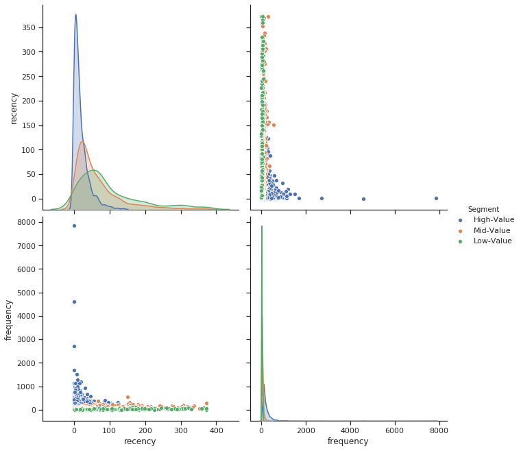

```python
#Figure 2
sns.set(style="ticks")
df_graph2 = segmented_rfm_3m.query("monetary_value < 50000 and OverallScore < 10")
sns.pairplot(df_graph[['recency','frequency','Segment']], hue="Segment",size=4.5)
plt.savefig("RF.png")
```

Puisque notre ensemble de fonctionnalités est prêt, calculons 6 mois de LTV pour chaque client que nous allons utiliser pour former notre modèle. Il n'y a aucun coût spécifié dans l'ensemble de données. C'est pourquoi Revenue devient notre LTV directement.

```python
df2_6m
```

|  | InvoiceNo | StockCode | Description | Quantity | InvoiceDate | UnitPrice | CustomerID | Country | TotalPrice |
| --- | --- | --- | --- | --- | --- | --- | --- | --- | --- |
| 0 | 555156 | 23299 | FOOD COVER WITH BEADS SET 2 | 6 | 2011-06-01 07:37:00 | 3.75 | 15643.0 | United Kingdom | 22.50 |
| 1 | 555156 | 22847 | BREAD BIN DINER STYLE IVORY | 1 | 2011-06-01 07:37:00 | 16.95 | 15643.0 | United Kingdom | 16.95 |
| 2 | 555157 | 23075 | PARLOUR CERAMIC WALL HOOK | 16 | 2011-06-01 07:38:00 | 4.15 | 15643.0 | United Kingdom | 66.40 |
| 3 | 555157 | 47590B | PINK HAPPY BIRTHDAY BUNTING | 6 | 2011-06-01 07:38:00 | 5.45 | 15643.0 | United Kingdom | 32.70 |
| 4 | 555157 | 22423 | REGENCY CAKESTAND 3 TIER | 4 | 2011-06-01 07:38:00 | 12.75 | 15643.0 | United Kingdom | 51.00 |
| ... | ... | ... | ... | ... | ... | ... | ... | ... | ... |
| 208593 | 579885 | 85034C | 3 ROSE MORRIS BOXED CANDLES | 4 | 2011-11-30 17:37:00 | 1.25 | 15444.0 | United Kingdom | 5.00 |
| 208594 | 579885 | 21742 | LARGE ROUND WICKER PLATTER | 2 | 2011-11-30 17:37:00 | 5.95 | 15444.0 | United Kingdom | 11.90 |
| 208595 | 579885 | 23084 | RABBIT NIGHT LIGHT | 6 | 2011-11-30 17:37:00 | 2.08 | 15444.0 | United Kingdom | 12.48 |
| 208596 | 579885 | 21257 | VICTORIAN SEWING BOX MEDIUM | 1 | 2011-11-30 17:37:00 | 7.95 | 15444.0 | United Kingdom | 7.95 |
| 208597 | 579885 | 21259 | VICTORIAN SEWING BOX SMALL | 1 | 2011-11-30 17:37:00 | 5.95 | 15444.0 | United Kingdom | 5.95 |

208598 rows × 9 columns

```python
#calculons les revenus et créer un nouveau cadre de données pour celui-ci

df2_6m['Revenue'] = df2_6m['UnitPrice'] * df2_6m['Quantity']
df2_user_6m = df2_6m.groupby('CustomerID')['Revenue'].sum().reset_index()
df2_user_6m.columns = ['CustomerID','m6_Revenue']
df2_6m.head()
```

|  | InvoiceNo | StockCode | Description | Quantity | InvoiceDate | UnitPrice | CustomerID | Country | TotalPrice | Revenue |
| --- | --- | --- | --- | --- | --- | --- | --- | --- | --- | --- |
| 0 | 555156 | 23299 | FOOD COVER WITH BEADS SET 2 | 6 | 2011-06-01 07:37:00 | 3.75 | 15643.0 | United Kingdom | 22.50 | 22.50 |
| 1 | 555156 | 22847 | BREAD BIN DINER STYLE IVORY | 1 | 2011-06-01 07:37:00 | 16.95 | 15643.0 | United Kingdom | 16.95 | 16.95 |
| 2 | 555157 | 23075 | PARLOUR CERAMIC WALL HOOK | 16 | 2011-06-01 07:38:00 | 4.15 | 15643.0 | United Kingdom | 66.40 | 66.40 |
| 3 | 555157 | 47590B | PINK HAPPY BIRTHDAY BUNTING | 6 | 2011-06-01 07:38:00 | 5.45 | 15643.0 | United Kingdom | 32.70 | 32.70 |
| 4 | 555157 | 22423 | REGENCY CAKESTAND 3 TIER | 4 | 2011-06-01 07:38:00 | 12.75 | 15643.0 | United Kingdom | 51.00 | 51.00 |

Cet extrait de code calcule la LTV et trace son histogramme:

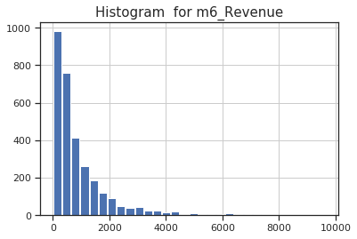

```python
#Figure 3
#Histogram
plt.figure()
plt.hist(df2_user_6m.query('m6_Revenue < 10000')['m6_Revenue'], bins = 30, rwidth = 0.9)
plt.title("Histogram  for m6_Revenue",size = 15)
plt.grid()
plt.show()
plt.savefig("m6_Revenue.png")
```

fusionnons nos trames de données de 3 mois et 6 mois pour voir les corrélations entre LTV et l'ensemble de fonctionnalités que nous avons.

```python
df2_merge = pd.merge(segmented_rfm_3m, df2_user_6m, on='CustomerID', how='left')
df2_merge.head()
```

|  | CustomerID | recency | frequency | monetary_value | r_quartile | f_quartile | m_quartile | RFMScore | OverallScore | Segment | m6_Revenue |
| --- | --- | --- | --- | --- | --- | --- | --- | --- | --- | --- | --- |
| 0 | 12747.0 | 6 | 35 | 1082.09 | 1 | 3 | 2 | 132 | 6 | Mid-Value | 1666.11 |
| 1 | 12748.0 | 0 | 559 | 4514.24 | 1 | 1 | 1 | 111 | 3 | High-Value | 23098.68 |
| 2 | 12749.0 | 21 | 43 | 859.10 | 2 | 2 | 2 | 222 | 6 | Mid-Value | 2468.72 |
| 3 | 12821.0 | 22 | 6 | 92.72 | 2 | 4 | 4 | 244 | 10 | Low-Value | NaN |
| 4 | 12823.0 | 62 | 1 | 459.00 | 3 | 4 | 3 | 343 | 10 | Low-Value | 765.00 |

```python
df2_merge = df2_merge.fillna(0)
df2_merge.groupby('Segment')['m6_Revenue'].mean()
```

```
Segment
High-Value    5507.199412
Low-Value      448.416434
Mid-Value     1350.251444
Name: m6_Revenue, dtype: float64
```

```python
df2_merge["Segment"].unique()
```

```
array(['Mid-Value', 'High-Value', 'Low-Value'], dtype=object)
```

Le code ci-dessous fusionne notre ensemble de fonctionnalités et les données LTV et trace le score LTV vs le score RFM global:

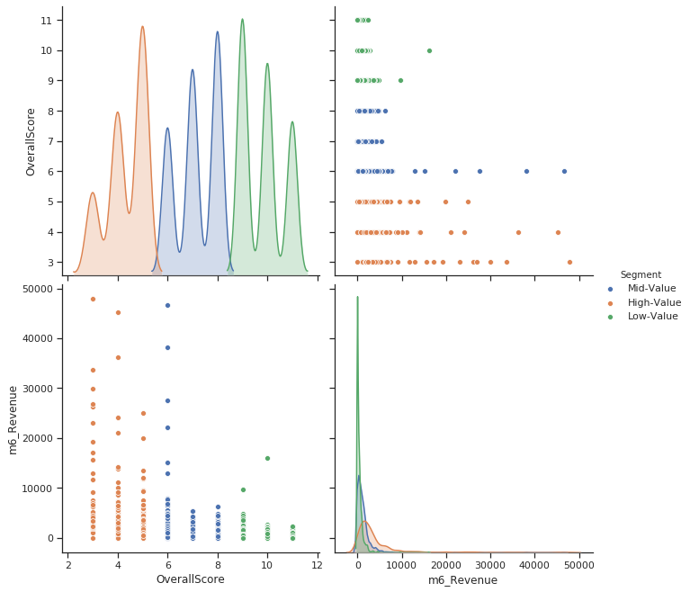

```python
#Figure 4
sns.set(style="ticks")
df_graph2 = df2_merge.query("m6_Revenue < 60000")
sns.pairplot(df_graph2, hue="Segment", vars=['OverallScore','m6_Revenue'],size=4.5)
plt.savefig("LTV.png")
```

Avant de construire le modèle d'apprentissage automatique, nous devons identifier quel est le type de ce problème d'apprentissage automatique. Le LTV lui-même est un problème de régression. Un modèle d'apprentissage automatique peut prédire la valeur $ du LTV. Mais ici, nous voulons des segments LTV. Parce que cela le rend plus exploitable et plus facile à communiquer avec d'autres personnes. En appliquant le clustering K-means, nous pouvons identifier nos groupes LTV existants et créer des segments par-dessus. Compte tenu de la partie commerciale de cette analyse, nous devons traiter les clients différemment en fonction de leur LTV prédite. Pour cet exemple, nous appliquerons le clustering et aurons 3 segments (le nombre de segments dépend vraiment de la dynamique et des objectifs de notre entreprise):

- Low LTV
- Mid LTV
- High LTV

Nous allons appliquer le clustering K-means pour décider des segments et observer leurs caractéristiques:

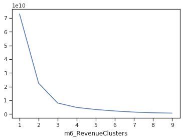

```python
sse={}
df2_m6_Revenue = df2_merge[['m6_Revenue']]
for k in range(1, 10):
    kmeans = KMeans(n_clusters=k, max_iter=1000).fit(df2_m6_Revenue)
    df2_m6_Revenue["m6_RevenueClusters"] = kmeans.labels_
    sse[k] = kmeans.inertia_
plt.figure()
plt.plot(list(sse.keys()), list(sse.values()))
plt.xlabel("m6_RevenueClusters")
plt.show()
```

```python
def order_cluster(cluster_field_name, target_field_name,df,ascending):
    new_cluster_field_name = 'new_' + cluster_field_name
    df_new = df.groupby(cluster_field_name)[target_field_name].mean().reset_index()
    df_new = df_new.sort_values(by=target_field_name,ascending=ascending).reset_index(drop=True)
    df_new['index'] = df_new.index
    df_final = pd.merge(df,df_new[[cluster_field_name,'index']], on=cluster_field_name)
    df_final = df_final.drop([cluster_field_name],axis=1)
    df_final = df_final.rename(columns={"index":cluster_field_name})
    return df_final
```

```python
#remove outliers
df2_merge = df2_merge[df2_merge['m6_Revenue']<df2_merge['m6_Revenue'].quantile(0.99)]

#creating 3 clusters
kmeans = KMeans(n_clusters=3)
kmeans.fit(df2_merge[['m6_Revenue']])
df2_merge['LTVCluster'] = kmeans.predict(df2_merge[['m6_Revenue']])

#order cluster number based on LTV
df2_merge = order_cluster('LTVCluster', 'm6_Revenue',df2_merge,True)

#creatinga new cluster dataframe
df2_cluster = df2_merge.copy()

#see details of the clusters
df2_cluster.groupby('LTVCluster')['m6_Revenue'].describe()
```

| LTVCluster | count | mean | std | min | 25% | 50% | 75% | max |
| --- | --- | --- | --- | --- | --- | --- | --- | --- |
| 0 | 1423.0 | 451.550450 | 471.859005 | 0.00 | 0.0000 | 320.12 | 765.3950 | 1638.68 |
| 1 | 324.0 | 2815.144506 | 1064.648531 | 1641.11 | 1969.3225 | 2516.45 | 3443.7075 | 6008.61 |
| 2 | 46.0 | 9245.749130 | 3153.808516 | 6149.32 | 6654.7550 | 7779.09 | 11482.0750 | 17101.04 |

## **Machine Learning Model LTV**

```python
df2_cluster=df2_cluster.drop(['r_quartile','f_quartile','m_quartile','RFMScore'],axis=1)
df2_cluster.head()
```

|  | CustomerID | recency | frequency | monetary_value | OverallScore | Segment | m6_Revenue | LTVCluster |
| --- | --- | --- | --- | --- | --- | --- | --- | --- |
| 0 | 12747.0 | 6 | 35 | 1082.09 | 6 | Mid-Value | 1666.11 | 1 |
| 1 | 12749.0 | 21 | 43 | 859.10 | 6 | Mid-Value | 2468.72 | 1 |
| 2 | 12839.0 | 6 | 23 | 306.88 | 7 | Mid-Value | 3443.14 | 1 |
| 3 | 12841.0 | 30 | 65 | 548.34 | 7 | Mid-Value | 1910.08 | 1 |
| 4 | 12867.0 | 22 | 150 | 951.59 | 5 | High-Value | 2298.28 | 1 |

**Encodage des variables cartégoriques**

```python
df2_cluster = pd.get_dummies(df2_cluster)
```

```python
df2_cluster.head()
```

|  | CustomerID | recency | frequency | monetary_value | OverallScore | m6_Revenue | LTVCluster | Segment_High-Value | Segment_Low-Value | Segment_Mid-Value |
| --- | --- | --- | --- | --- | --- | --- | --- | --- | --- | --- |
| 0 | 12747.0 | 6 | 35 | 1082.09 | 6 | 1666.11 | 1 | 0 | 0 | 1 |
| 1 | 12749.0 | 21 | 43 | 859.10 | 6 | 2468.72 | 1 | 0 | 0 | 1 |
| 2 | 12839.0 | 6 | 23 | 306.88 | 7 | 3443.14 | 1 | 0 | 0 | 1 |
| 3 | 12841.0 | 30 | 65 | 548.34 | 7 | 1910.08 | 1 | 0 | 0 | 1 |
| 4 | 12867.0 | 22 | 150 | 951.59 | 5 | 2298.28 | 1 | 1 | 0 | 0 |

**Analyse de correlation**

```python
corr_matrix = df2_cluster.corr()
corr_matrix['LTVCluster'].sort_values(ascending=False)
```

```
LTVCluster            1.000000
m6_Revenue            0.848500
monetary_value        0.528025
Segment_High-Value    0.473019
frequency             0.352587
Segment_Mid-Value     0.007522
CustomerID           -0.028890
recency              -0.232371
Segment_Low-Value    -0.339341
OverallScore         -0.505672
Name: LTVCluster, dtype: float64
```

```python
X = df2_cluster.drop(['LTVCluster','m6_Revenue'],axis=1)
y = df2_cluster['LTVCluster']
```

**Division en training et test set**

```python
X_train, X_test, y_train, y_test = train_test_split(X, y, test_size=0.05, random_state=56)
```

```python
#XGBoost Multiclassification Model
ltv_xgb_model = xgb.XGBClassifier(max_depth=5, learning_rate=0.1,objective= 'multi:softprob',n_jobs=-1).fit(X_train, y_train)

print('Accuracy of XGB classifier on training set: {:.2f}'
       .format(ltv_xgb_model.score(X_train, y_train)))
print('Accuracy of XGB classifier on test set: {:.2f}'
       .format(ltv_xgb_model.score(X_test[X_train.columns], y_test)))

y_pred = ltv_xgb_model.predict(X_test)
print(classification_report(y_test, y_pred))
```

```
Accuracy of XGB classifier on training set: 0.92
Accuracy of XGB classifier on test set: 0.86
              precision    recall  f1-score   support

           0       0.91      0.93      0.92        76
           1       0.55      0.46      0.50        13
           2       0.00      0.00      0.00         1

    accuracy                           0.86        90
   macro avg       0.49      0.47      0.47        90
weighted avg       0.85      0.86      0.85        90
```

```python
df2_cluster.groupby('LTVCluster').CustomerID.count()/df2_cluster.CustomerID.count()
```

```
LTVCluster
0    0.793642
1    0.180703
2    0.025655
Name: CustomerID, dtype: float64
```

- Ajouter plus de fonctionnalités et améliorer l'ingénierie des fonctionnalités Essayez différents modèles autres que XGBoost Appliquer un réglage hyper paramétrique au modèle actuel
- Ajoutez plus de données au modèle si possible

Génial! Nous avons maintenant un modèle d'apprentissage automatique qui prédit les futurs segments LTV de nos clients. Nous pouvons facilement adapter nos actions en fonction de cela. Par exemple, nous ne voulons certainement pas perdre des clients avec un LTV élevé. Nous allons donc nous concentrer sur la prédiction de désabonnement.

# **Prédiction du prochain jour d'achat**

Traitez nos clients d'une manière qu'ils méritent avant qu'ils ne s'y attendent (par exemple, prédiction LTV) et agissons avant que quelque chose de mauvais ne se produise (par exemple, le taux de désabonnement).

L'analyse prédictive nous aide beaucoup sur celui-ci. L'une des nombreuses opportunités qu'il peut offrir est de prévoir le prochain jour d'achat du client. Que faire si nous savons si un client est susceptible de faire un nouvel achat dans 7 jours?

Nous pouvons construire notre stratégie en plus de cela et proposer de nombreuses actions tactiques comme:

- Aucune offre promotionnelle à ce client car il fera quand même un achat
- Poussez le client avec le marketing entrant s'il n'y a pas d'achat dans la fenêtre de temps prévue

[figure not shown]

df_6m représente la performance de six mois mais nous utiliserons df_next pour connaître les jours entre la dernière date d'achat dans df_6m et la première dans df_next.

```python
df_6m = df2[(df2.InvoiceDate < date(2011,9,1)) & (df2.InvoiceDate >= date(2011,3,1))].reset_index(drop=True)
df_next = df2[(df2.InvoiceDate >= date(2011,9,1)) & (df2.InvoiceDate < date(2011,12,1))].reset_index(drop=True)
```

```python
df_next['InvoiceDate'].describe()
```

```
count                  138180
unique                   5227
top       2011-11-14 15:27:00
freq                      542
first     2011-09-01 08:25:00
last      2011-11-30 17:37:00
Name: InvoiceDate, dtype: object
```

Nous allons créer une trame de données appelée df_user pour posséder un ensemble de fonctionnalités de niveau utilisateur pour le modèle de prédiction:

```python
df_user = pd.DataFrame(df_6m['CustomerID'].unique())
df_user.columns = ['CustomerID']
```

En utilisant les données dans df_next, nous avons besoin de calculer notre étiquette (jours entre le dernier achat avant la date limite et le premier achat après cela):

```python
#create a dataframe with customer id and first purchase date in tx_next
df_next_first_purchase = df_next.groupby('CustomerID').InvoiceDate.min().reset_index()
df_next_first_purchase.columns = ['CustomerID','MinPurchaseDate']

#create a dataframe with customer id and last purchase date in tx_6m
df_last_purchase = df_6m.groupby('CustomerID').InvoiceDate.max().reset_index()
df_last_purchase.columns = ['CustomerID','MaxPurchaseDate']

#merge two dataframes
df_purchase_dates = pd.merge(df_last_purchase,df_next_first_purchase,on='CustomerID',how='left')

#calculate the time difference in days:
df_purchase_dates['NextPurchaseDay'] = (df_purchase_dates['MinPurchaseDate'] - df_purchase_dates['MaxPurchaseDate']).dt.days

df_purchase_dates.head()
```

|  | CustomerID | MaxPurchaseDate | MinPurchaseDate | NextPurchaseDay |
| --- | --- | --- | --- | --- |
| 0 | 12747.0 | 2011-08-22 10:38:00 | 2011-10-04 08:26:00 | 42.0 |
| 1 | 12748.0 | 2011-08-30 12:00:00 | 2011-09-02 10:49:00 | 2.0 |
| 2 | 12749.0 | 2011-08-01 12:50:00 | 2011-11-17 12:05:00 | 107.0 |
| 3 | 12821.0 | 2011-05-09 15:51:00 | NaT | NaN |
| 4 | 12823.0 | 2011-08-04 17:45:00 | 2011-09-26 07:35:00 | 52.0 |

```python
#merge with df_user
df_user = pd.merge(df_user, df_purchase_dates[['CustomerID','NextPurchaseDay']],on='CustomerID',how='left')
#print tx_user
df_user.head()
```

|  | CustomerID | NextPurchaseDay |
| --- | --- | --- |
| 0 | 14620.0 | NaN |
| 1 | 14740.0 | NaN |
| 2 | 13880.0 | 57.0 |
| 3 | 16462.0 | 111.0 |
| 4 | 17068.0 | 16.0 |

Nous remplissons NaN avec 999 pour les identifier rapidement plus tard.

```python
#fill NA values with 999
df_user = df_user.fillna(999)
df_user
```

|  | CustomerID | NextPurchaseDay |
| --- | --- | --- |
| 0 | 14620.0 | 999.0 |
| 1 | 14740.0 | 999.0 |
| 2 | 13880.0 | 57.0 |
| 3 | 16462.0 | 111.0 |
| 4 | 17068.0 | 16.0 |
| ... | ... | ... |
| 2535 | 16083.0 | 999.0 |
| 2536 | 13726.0 | 61.0 |
| 2537 | 15690.0 | 999.0 |
| 2538 | 17777.0 | 60.0 |
| 2539 | 16278.0 | 999.0 |

2540 rows × 2 columns

Nous avons des identifiants clients et des étiquettes correspondantes dans une trame de données. Enrichissons-le avec notre ensemble de fonctionnalités pour construire notre modèle d'apprentissage automatique.

## **Machine Learning Model NextPurchaseDay**

### **Ingénierie des fonctionnalités**

Pour ce projet, nous avons sélectionné nos candidats vedettes comme ci-dessous:

- Scores et clusters RFM
- Jours entre les trois derniers achats
- Écart moyen et standard de la différence entre les achats en jours

Après avoir ajouté ces fonctionnalités, nous devons traiter les fonctionnalités catégorielles en appliquant la méthode get_dummies .

```python
#Découvrons les dates de première et dernière commande dans les données.
df_6m['InvoiceDate'].min()
```

```
Timestamp('2011-03-01 08:30:00')
```

```python
df_6m['InvoiceDate'].max()
```

```
Timestamp('2011-08-31 17:16:00')
```

```python
NOW = dt.datetime(2011,9,1)
df_6m['InvoiceDate'] = pd.to_datetime(df_6m['InvoiceDate'])
```

```python
rfmTable_df_6m = df_6m.groupby('CustomerID').agg({'InvoiceDate': lambda x: (NOW - x.max()).days,
                                        'InvoiceNo': lambda x: len(x),
                                        'TotalPrice': lambda x: x.sum()})

rfmTable_df_6m['InvoiceDate'] = rfmTable_df_6m['InvoiceDate'].astype(int)
rfmTable_df_6m.rename(columns={'InvoiceDate': 'recency',
                         'InvoiceNo': 'frequency',
                         'TotalPrice': 'monetary_value'}, inplace=True)
rfmTable_df_6m.head()
```

| CustomerID | recency | frequency | monetary_value |
| --- | --- | --- | --- |
| 12747.0 | 9 | 50 | 1760.09 |
| 12748.0 | 1 | 1183 | 8532.01 |
| 12749.0 | 30 | 128 | 2755.23 |
| 12821.0 | 114 | 6 | 92.72 |
| 12823.0 | 27 | 2 | 688.50 |

```python
segmented_rfm_6m = rfmTable_df_6m.reset_index()
```

```python
#Ajoutons des numéros de segment à la table RFM segmentée nouvellement créée
segmented_rfm_6m['r_quartile'] = segmented_rfm_6m['recency'].apply(RScore, args=('recency',quantiles,))
segmented_rfm_6m['f_quartile'] = segmented_rfm_6m['frequency'].apply(FMScore, args=('frequency',quantiles,))
segmented_rfm_6m['m_quartile'] = segmented_rfm_6m['monetary_value'].apply(FMScore, args=('monetary_value',quantiles,))
segmented_rfm_6m.head()

segmented_rfm_6m['RFMScore'] = segmented_rfm_6m.r_quartile.map(str)+ segmented_rfm_6m.f_quartile.map(str)+ segmented_rfm_6m.m_quartile.map(str)
segmented_rfm_6m['OverallScore'] = segmented_rfm_6m.r_quartile+ segmented_rfm_6m.f_quartile+ segmented_rfm_6m.m_quartile
segmented_rfm_6m.groupby('OverallScore')['recency','frequency','monetary_value'].mean()
segmented_rfm_6m.head()
```

|  | CustomerID | recency | frequency | monetary_value | r_quartile | f_quartile | m_quartile | RFMScore | OverallScore |
| --- | --- | --- | --- | --- | --- | --- | --- | --- | --- |
| 0 | 12747.0 | 9 | 50 | 1760.09 | 1 | 2 | 1 | 121 | 4 |
| 1 | 12748.0 | 1 | 1183 | 8532.01 | 1 | 1 | 1 | 111 | 3 |
| 2 | 12749.0 | 30 | 128 | 2755.23 | 2 | 1 | 1 | 211 | 4 |
| 3 | 12821.0 | 114 | 6 | 92.72 | 3 | 4 | 4 | 344 | 11 |
| 4 | 12823.0 | 27 | 2 | 688.50 | 2 | 4 | 2 | 242 | 8 |

```python
segmented_rfm_6m.groupby('OverallScore')['recency'].count()
```

```
OverallScore
3     132
4     167
5     193
6     248
7     285
8     281
9     367
10    351
11    365
12    151
Name: recency, dtype: int64
```

```python
segmented_rfm_6m['Segment'] = 'Low-Value'
segmented_rfm_6m.loc[segmented_rfm_6m['OverallScore']<9,'Segment'] = 'Mid-Value'
segmented_rfm_6m.loc[segmented_rfm_6m['OverallScore']<6,'Segment'] = 'High-Value'
```

Le code ci-dessous trace le score RFM vs monetary_value (la valeur monétaire):

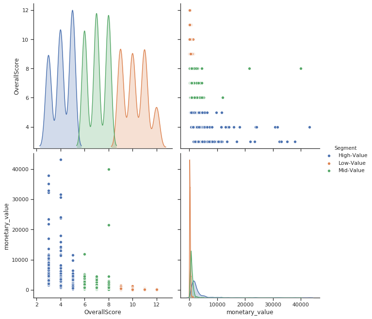

```python
#Figure 5
sns.set(style="ticks")
df_graph3 = segmented_rfm_6m.query("monetary_value < 60000 and frequency < 2000")
sns.pairplot(df_graph3, hue="Segment", vars=['OverallScore','monetary_value'],size=4.5)
plt.savefig("PD.png")
```

Concentrons-nous sur la façon dont nous pouvons ajouter les deux fonctionnalités suivantes. Nous utiliserons beaucoup la méthode shift () dans cette partie. Tout d'abord, nous créons une trame de données avec l'ID client et le jour de la facture sans l'heure . Ensuite, nous supprimerons les doublons car les clients peuvent effectuer plusieurs achats en une journée et la différence deviendra nulle pour ceux-ci.

```python
df_user = pd.merge(df_user, segmented_rfm_6m, on='CustomerID')
df_user.head()
```

|  | CustomerID | NextPurchaseDay | recency | frequency | monetary_value | r_quartile | f_quartile | m_quartile | RFMScore | OverallScore | Segment |
| --- | --- | --- | --- | --- | --- | --- | --- | --- | --- | --- | --- |
| 0 | 14620.0 | 999.0 | 105 | 26 | 412.78 | 3 | 3 | 3 | 333 | 9 | Low-Value |
| 1 | 14740.0 | 999.0 | 97 | 89 | 1448.21 | 3 | 2 | 2 | 322 | 7 | Mid-Value |
| 2 | 13880.0 | 57.0 | 45 | 71 | 1372.76 | 2 | 2 | 2 | 222 | 6 | Mid-Value |
| 3 | 16462.0 | 111.0 | 85 | 2 | 68.00 | 3 | 4 | 4 | 344 | 11 | Low-Value |
| 4 | 17068.0 | 16.0 | 10 | 139 | 2426.34 | 1 | 1 | 1 | 111 | 3 | High-Value |

```python
#create a dataframe with CustomerID and Invoice Date
df_day_order = df_6m[['CustomerID','InvoiceDate']]
#convert Invoice Datetime to day
df_day_order['InvoiceDay'] = df_6m['InvoiceDate'].dt.date
df_day_order =df_day_order.sort_values(['CustomerID','InvoiceDate'])
#drop duplicates
df_day_order = df_day_order.drop_duplicates(subset=['CustomerID','InvoiceDay'],keep='first')
df_day_order.head()
```

|  | CustomerID | InvoiceDate | InvoiceDay |
| --- | --- | --- | --- |
| 548 | 12747.0 | 2011-03-01 14:53:00 | 2011-03-01 |
| 47953 | 12747.0 | 2011-05-05 15:31:00 | 2011-05-05 |
| 66424 | 12747.0 | 2011-05-25 09:57:00 | 2011-05-25 |
| 91559 | 12747.0 | 2011-06-28 10:06:00 | 2011-06-28 |
| 133406 | 12747.0 | 2011-08-22 10:38:00 | 2011-08-22 |

Ensuite, en utilisant shift, nous créons de nouvelles colonnes avec les dates des 3 derniers achats et voyons à quoi ressemble notre dataframe:

```python
#shifting last 3 purchase dates
df_day_order['PrevInvoiceDate'] = df_day_order.groupby('CustomerID')['InvoiceDay'].shift(1)
df_day_order['T2InvoiceDate'] = df_day_order.groupby('CustomerID')['InvoiceDay'].shift(2)
df_day_order['T3InvoiceDate'] = df_day_order.groupby('CustomerID')['InvoiceDay'].shift(3)
df_day_order.head()
```

|  | CustomerID | InvoiceDate | InvoiceDay | PrevInvoiceDate | T2InvoiceDate | T3InvoiceDate |
| --- | --- | --- | --- | --- | --- | --- |
| 548 | 12747.0 | 2011-03-01 14:53:00 | 2011-03-01 | NaN | NaN | NaN |
| 47953 | 12747.0 | 2011-05-05 15:31:00 | 2011-05-05 | 2011-03-01 | NaN | NaN |
| 66424 | 12747.0 | 2011-05-25 09:57:00 | 2011-05-25 | 2011-05-05 | 2011-03-01 | NaN |
| 91559 | 12747.0 | 2011-06-28 10:06:00 | 2011-06-28 | 2011-05-25 | 2011-05-05 | 2011-03-01 |
| 133406 | 12747.0 | 2011-08-22 10:38:00 | 2011-08-22 | 2011-06-28 | 2011-05-25 | 2011-05-05 |

Commençons par calculer la différence en jours pour chaque date de facturation:

```python
df_day_order['DayDiff'] = (df_day_order['InvoiceDay'] - df_day_order['PrevInvoiceDate']).dt.days
df_day_order['DayDiff2'] = (df_day_order['InvoiceDay'] - df_day_order['T2InvoiceDate']).dt.days
df_day_order['DayDiff3'] = (df_day_order['InvoiceDay'] - df_day_order ['T3InvoiceDate']).dt.days
df_day_order.head()
```

|  | CustomerID | InvoiceDate | InvoiceDay | PrevInvoiceDate | T2InvoiceDate | T3InvoiceDate | DayDiff | DayDiff2 | DayDiff3 |
| --- | --- | --- | --- | --- | --- | --- | --- | --- | --- |
| 548 | 12747.0 | 2011-03-01 14:53:00 | 2011-03-01 | NaN | NaN | NaN | NaN | NaN | NaN |
| 47953 | 12747.0 | 2011-05-05 15:31:00 | 2011-05-05 | 2011-03-01 | NaN | NaN | 65.0 | NaN | NaN |
| 66424 | 12747.0 | 2011-05-25 09:57:00 | 2011-05-25 | 2011-05-05 | 2011-03-01 | NaN | 20.0 | 85.0 | NaN |
| 91559 | 12747.0 | 2011-06-28 10:06:00 | 2011-06-28 | 2011-05-25 | 2011-05-05 | 2011-03-01 | 34.0 | 54.0 | 119.0 |
| 133406 | 12747.0 | 2011-08-22 10:38:00 | 2011-08-22 | 2011-06-28 | 2011-05-25 | 2011-05-05 | 55.0 | 89.0 | 109.0 |

Pour chaque ID client, nous utilisons la méthode .agg () pour connaître la moyenne et l'écart type de la différence entre les achats en jours:

```python
df_day_diff = df_day_order.groupby('CustomerID').agg({'DayDiff':['mean', 'std']}).reset_index ()
df_day_diff.columns =['CustomerID','DayDiffMean','DayDiffStd']
```

Maintenant, nous allons prendre une décision difficile. Le calcul ci-dessus est très utile pour les clients qui ont de nombreux achats. Mais nous ne pouvons pas en dire autant de ceux avec 1 à 2 achats. Par exemple, il est trop tôt pour marquer un client comme fréquent qui n'a que 2 achats.

Nous ne gardons que les clients qui ont> 3 achats en utilisant la ligne suivante:

```python
df_day_order_last = df_day_order.drop_duplicates(subset=['CustomerID'],keep='last')
```

Enfin, nous supprimons les valeurs NA, fusionnons les nouveaux cadres de données avec df_user et appliquons .get_dummies () pour convertir les valeurs catégorielles:

```python
df_day_order_last = df_day_order_last.dropna()
df_day_order_last = pd.merge(df_day_order_last, df_day_diff, on='CustomerID')
```

```python
df_user = pd.merge(df_user, df_day_order_last[['CustomerID','DayDiff','DayDiff2','DayDiff3','DayDiffMean','DayDiffStd']], on='CustomerID')
df_user.head()
```

|  | CustomerID | NextPurchaseDay | recency | frequency | monetary_value | r_quartile | f_quartile | m_quartile | RFMScore | OverallScore | Segment | DayDiff | DayDiff2 | DayDiff3 | DayDiffMean | DayDiffStd |
| --- | --- | --- | --- | --- | --- | --- | --- | --- | --- | --- | --- | --- | --- | --- | --- | --- |
| 0 | 13880.0 | 57.0 | 45 | 71 | 1372.76 | 2 | 2 | 2 | 222 | 6 | Mid-Value | 41.0 | 72.0 | 93.0 | 34.500000 | 10.754844 |
| 1 | 17068.0 | 16.0 | 10 | 139 | 2426.34 | 1 | 1 | 1 | 111 | 3 | High-Value | 25.0 | 37.0 | 38.0 | 17.300000 | 11.045864 |
| 2 | 12971.0 | 8.0 | 7 | 145 | 6179.19 | 1 | 1 | 1 | 111 | 3 | High-Value | 3.0 | 7.0 | 19.0 | 5.333333 | 3.619968 |
| 3 | 16915.0 | 83.0 | 27 | 31 | 382.39 | 2 | 3 | 3 | 233 | 8 | Mid-Value | 41.0 | 121.0 | 156.0 | 52.000000 | 24.433583 |
| 4 | 15194.0 | 39.0 | 26 | 105 | 2263.42 | 2 | 1 | 1 | 211 | 4 | High-Value | 44.0 | 72.0 | 91.0 | 31.400000 | 9.181503 |

```python
df_class=df_user.copy()
df_class=df_class.drop(['r_quartile','f_quartile','m_quartile','RFMScore'],axis=1)
df_class = pd.get_dummies(df_class)
```

```python
df_class.head()
```

|  | CustomerID | NextPurchaseDay | recency | frequency | monetary_value | OverallScore | DayDiff | DayDiff2 | DayDiff3 | DayDiffMean | DayDiffStd | Segment_High-Value | Segment_Low-Value | Segment_Mid-Value |
| --- | --- | --- | --- | --- | --- | --- | --- | --- | --- | --- | --- | --- | --- | --- |
| 0 | 13880.0 | 57.0 | 45 | 71 | 1372.76 | 6 | 41.0 | 72.0 | 93.0 | 34.500000 | 10.754844 | 0 | 0 | 1 |
| 1 | 17068.0 | 16.0 | 10 | 139 | 2426.34 | 3 | 25.0 | 37.0 | 38.0 | 17.300000 | 11.045864 | 1 | 0 | 0 |
| 2 | 12971.0 | 8.0 | 7 | 145 | 6179.19 | 3 | 3.0 | 7.0 | 19.0 | 5.333333 | 3.619968 | 1 | 0 | 0 |
| 3 | 16915.0 | 83.0 | 27 | 31 | 382.39 | 8 | 41.0 | 121.0 | 156.0 | 52.000000 | 24.433583 | 0 | 0 | 1 |
| 4 | 15194.0 | 39.0 | 26 | 105 | 2263.42 | 4 | 44.0 | 72.0 | 91.0 | 31.400000 | 9.181503 | 1 | 0 | 0 |

```python
df_user.NextPurchaseDay.describe()
```

```
count    490.000000
mean     137.816327
std      285.477963
min        0.000000
25%       23.000000
50%       40.000000
75%       71.750000
max      999.000000
Name: NextPurchaseDay, dtype: float64
```

Décider des limites est une question à la fois pour les statistiques et les besoins des entreprises. Il devrait avoir un sens par rapport au premier et être facile à prendre et à communiquer. Compte tenu de ces deux, nous aurons trois classes:

- 0-20: les clients qui achèteront dans 0-20 jours -: 2
- 21–49: Clients qui achèteront dans 21–49 jours - : 1
- ≥ 50: Clients qui achèteront dans plus de 50 jours - : 0

```python
df_class['NextPurchaseDayRange'] = 2
df_class.loc[df_class.NextPurchaseDay>20,'NextPurchaseDayRange'] = 1
df_class.loc[df_class.NextPurchaseDay>50,'NextPurchaseDayRange'] = 0
```

```python
df_class.dropna()
df_class.head()
```

|  | CustomerID | NextPurchaseDay | recency | frequency | monetary_value | OverallScore | DayDiff | DayDiff2 | DayDiff3 | DayDiffMean | DayDiffStd | Segment_High-Value | Segment_Low-Value | Segment_Mid-Value | NextPurchaseDayRange |
| --- | --- | --- | --- | --- | --- | --- | --- | --- | --- | --- | --- | --- | --- | --- | --- |
| 0 | 13880.0 | 57.0 | 45 | 71 | 1372.76 | 6 | 41.0 | 72.0 | 93.0 | 34.500000 | 10.754844 | 0 | 0 | 1 | 0 |
| 1 | 17068.0 | 16.0 | 10 | 139 | 2426.34 | 3 | 25.0 | 37.0 | 38.0 | 17.300000 | 11.045864 | 1 | 0 | 0 | 2 |
| 2 | 12971.0 | 8.0 | 7 | 145 | 6179.19 | 3 | 3.0 | 7.0 | 19.0 | 5.333333 | 3.619968 | 1 | 0 | 0 | 2 |
| 3 | 16915.0 | 83.0 | 27 | 31 | 382.39 | 8 | 41.0 | 121.0 | 156.0 | 52.000000 | 24.433583 | 0 | 0 | 1 | 0 |
| 4 | 15194.0 | 39.0 | 26 | 105 | 2263.42 | 4 | 44.0 | 72.0 | 91.0 | 31.400000 | 9.181503 | 1 | 0 | 0 | 1 |

La dernière étape consiste à voir la corrélation entre nos fonctionnalités et notre étiquette. La matrice de corrélation est l'un des moyens les plus propres de le montrer:

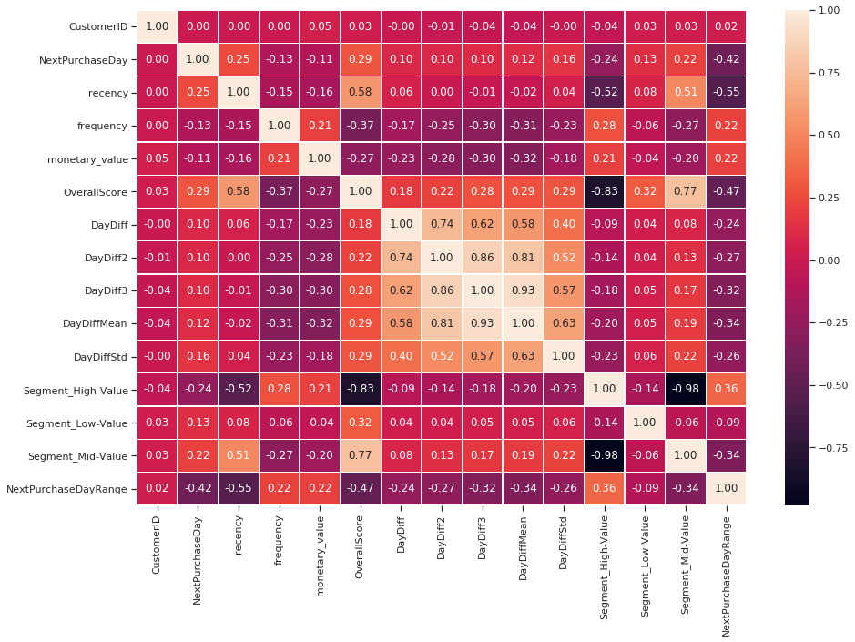

```python
corr = df_class[df_class.columns].corr()
plt.figure(figsize = (15,10))
sns.heatmap(corr, annot = True, linewidths=0.2, fmt=".2f")
```

On dirait que le segment_high_value a la corrélation positive la plus élevée (0,36) et que la récence a le plus haut négatif (-0,55). Pour ce problème particulier, nous voulons utiliser le modèle qui donne la plus grande précision. Séparons les tests de train et de test et mesurons la précision de différents modèles:

```python
df_class = df_class.drop('NextPurchaseDay',axis=1)
```

```python
len(df_class)
```

```
490
```

```python
X, y = df_class.drop('NextPurchaseDayRange',axis=1), df_class.NextPurchaseDayRange
X_train, X_test, y_train, y_test = train_test_split(X, y, test_size=0.2, random_state=44)
```

```python
models = []
models.append(("LR",LogisticRegression()))
models.append(("NB",GaussianNB()))
models.append(("RF",RandomForestClassifier()))
models.append(("SVC",SVC()))
models.append(("Dtree",DecisionTreeClassifier()))
models.append(("XGB",xgb.XGBClassifier()))
models.append(("KNN",KNeighborsClassifier()))

for name,model in models:
    kfold = KFold(n_splits=2, random_state=22)
    cv_result = cross_val_score(model,X_train,y_train, cv = kfold,scoring = "accuracy")
    print(name, cv_result)
```

```
LR [0.58163265 0.57142857]
NB [0.59183673 0.60714286]
RF [0.55612245 0.57653061]
SVC [0.40816327 0.46938776]
Dtree [0.51530612 0.62244898]
XGB [0.54591837 0.58163265]
KNN [0.35204082 0.39285714]
```

```python
xgb_model = xgb.XGBClassifier().fit(X_train, y_train)

print('Accuracy of XGB classifier on training set: {:.2f}'
       .format(xgb_model.score(X_train, y_train)))
print('Accuracy of XGB classifier on test set: {:.2f}'
       .format(xgb_model.score(X_test[X_train.columns], y_test)))
```

```
Accuracy of XGB classifier on training set: 0.93
Accuracy of XGB classifier on test set: 0.50
```

```python
y_pred = xgb_model.predict(X_test)
```

```python
print(classification_report(y_test, y_pred))
```

```
              precision    recall  f1-score   support

           0       0.67      0.56      0.61        39
           1       0.42      0.53      0.47        38
           2       0.41      0.33      0.37        21

    accuracy                           0.50        98
   macro avg       0.50      0.47      0.48        98
weighted avg       0.52      0.50      0.50        98
```

```python
param_test1 = {
 'max_depth':range(3,10,2),
 'min_child_weight':range(1,6,2)
}
gsearch1 = GridSearchCV(estimator = xgb.XGBClassifier(),
param_grid = param_test1, scoring='accuracy',n_jobs=-1,iid=False, cv=2)
gsearch1.fit(X_train,y_train)
gsearch1.best_params_, gsearch1.best_score_
```

```
({'max_depth': 3, 'min_child_weight': 3}, 0.5841836734693877)
```

```python
xgb_model = xgb.XGBClassifier(max_depth=3, min_child_weight=3).fit(X_train, y_train)

print('Accuracy of XGB classifier on training set: {:.2f}'
       .format(xgb_model.score(X_train, y_train)))
print('Accuracy of XGB classifier on test set: {:.2f}'
       .format(xgb_model.score(X_test[X_train.columns], y_test)))
```

```
Accuracy of XGB classifier on training set: 0.91
Accuracy of XGB classifier on test set: 0.49
```

```python
y_pred = xgb_model.predict(X_test)
```

```python
print(classification_report(y_test, y_pred))
```

```
              precision    recall  f1-score   support

           0       0.63      0.56      0.59        39
           1       0.39      0.47      0.43        38
           2       0.47      0.38      0.42        21

    accuracy                           0.49        98
   macro avg       0.50      0.47      0.48        98
weighted avg       0.50      0.49      0.49        98
```

# **Prédirection des ventes**

[figure not shown]

Que l'on souhaite prédire l'évolution des marchés financiers ou la consommation d'électricité, le temps est un facteur important qui doit désormais être pris en compte dans nos modèles. Par exemple, il serait intéressant de prévoir à quelle heure de la journée il y aura une pique d'achat, par exemple pour ajuster le prix ou le stock.

Une série chronologique est simplement une série de points de données ordonnés dans le temps. Dans une série chronologique, le temps est souvent la variable indépendante et l'objectif est généralement de faire des prévisions pour l'avenir. Cependant, il existe d'autres aspects qui entrent en jeu lorsqu'il s'agit de séries chronologiques.

**Est-elle stationnaire ?**

**Y a-t-il une saisonnalité ?**

**La variable cible est-elle auto-corrélée?**

### **Analyse exploratoire des données (EDA)**

```python
df_sales=df1[['InvoiceDate','Quantity','UnitPrice']]
df_sales['sales'] = df_sales['UnitPrice'] * df_sales['Quantity']
df_sales=df_sales[['InvoiceDate','sales']]
df_sales.head()
```

|  | InvoiceDate | sales |
| --- | --- | --- |
| 0 | 2010-12-01 08:26:00 | 15.30 |
| 1 | 2010-12-01 08:26:00 | 20.34 |
| 2 | 2010-12-01 08:26:00 | 22.00 |
| 3 | 2010-12-01 08:26:00 | 20.34 |
| 4 | 2010-12-01 08:26:00 | 20.34 |

```python
df_sales = df_sales.groupby('InvoiceDate')['sales'].sum().reset_index()
```

```python
df_sales.head()
```

|  | InvoiceDate | sales |
| --- | --- | --- |
| 0 | 2010-12-01 08:26:00 | 139.12 |
| 1 | 2010-12-01 08:28:00 | 22.20 |
| 2 | 2010-12-01 08:34:00 | 348.78 |
| 3 | 2010-12-01 08:35:00 | 17.85 |
| 4 | 2010-12-01 09:00:00 | 204.00 |

**Indexation avec des données de séries chronologiques**

```python
timeSeries=df_sales
timeSeries = timeSeries.set_index('InvoiceDate')
timeSeries.index
```

```
DatetimeIndex(['2010-12-01 08:26:00', '2010-12-01 08:28:00',
               '2010-12-01 08:34:00', '2010-12-01 08:35:00',
               '2010-12-01 09:00:00', '2010-12-01 09:01:00',
               '2010-12-01 09:02:00', '2010-12-01 09:09:00',
               '2010-12-01 09:32:00', '2010-12-01 09:34:00',
               ...
               '2011-12-09 11:56:00', '2011-12-09 12:00:00',
               '2011-12-09 12:08:00', '2011-12-09 12:19:00',
               '2011-12-09 12:20:00', '2011-12-09 12:21:00',
               '2011-12-09 12:23:00', '2011-12-09 12:25:00',
               '2011-12-09 12:31:00', '2011-12-09 12:49:00'],
              dtype='datetime64[ns]', name='InvoiceDate', length=15615, freq=None)
```

```python
timeSeries=timeSeries['sales'].resample('d').mean()
```

Ayez un aperçu rapide des données de vente 2010

```python
timeSeries=timeSeries.fillna(0)
timeSeries['2010':]
```

```
InvoiceDate
2010-12-01     410.036699
2010-12-02     371.170709
2010-12-03     482.966410
2010-12-04       0.000000
2010-12-05     364.082394
                 ...
2011-12-05     566.115876
2011-12-06     467.437778
2011-12-07     623.461646
2011-12-08     471.473700
2011-12-09    6412.956429
Freq: D, Name: sales, Length: 374, dtype: float64
```

**Visualisation des données des séries chronologiques de vente**

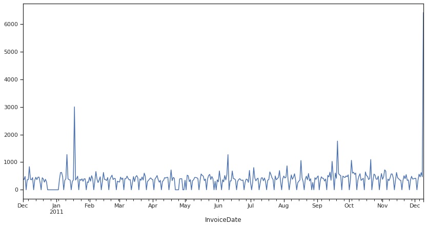

```python
timeSeries.plot (figsize = (14, 7))
plt.show ()
```

De toute évidence, nous voyons que ce n'est pas un processus stationnaire , et il est difficile de dire s'il existe une sorte de saisonnalité .

**Moyenne mobile**

Utilisons le modèle de moyenne mobile pour lisser nos séries chronologiques. Pour cela, nous utiliserons une fonction d'assistance qui exécutera le modèle de moyenne mobile sur une fenêtre de temps spécifiée et tracera la courbe lissée du résultat:

```python
def plot_moving_average(series, window, plot_intervals=False, scale=1.96):

    rolling_mean = series.rolling(window=window).mean()

    plt.figure(figsize=(14,7))
    plt.title('Moving average\n window size = {}'.format(window))
    plt.plot(rolling_mean, 'g', label='Rolling mean trend')

    #Plot confidence intervals for smoothed values
    if plot_intervals:
        mae = mean_absolute_error(series[window:], rolling_mean[window:])
        deviation = np.std(series[window:] - rolling_mean[window:])
        lower_bound = rolling_mean - (mae + scale * deviation)
        upper_bound = rolling_mean + (mae + scale * deviation)
        plt.plot(upper_bound, 'r--', label='Upper bound / Lower bound')
        plt.plot(lower_bound, 'r--')

    plt.plot(series[window:], label='Actual values')
    plt.legend(loc='best')
    plt.grid(True)
```

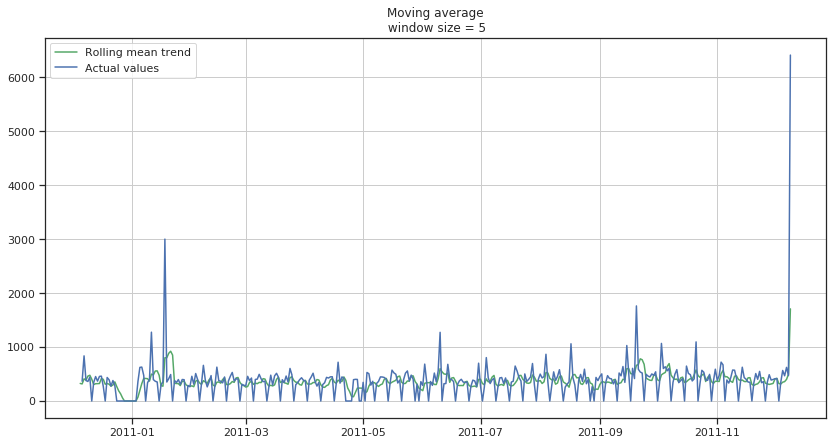

```python
#Smooth by the previous 5 days (by week)
plot_moving_average(timeSeries,5)
```

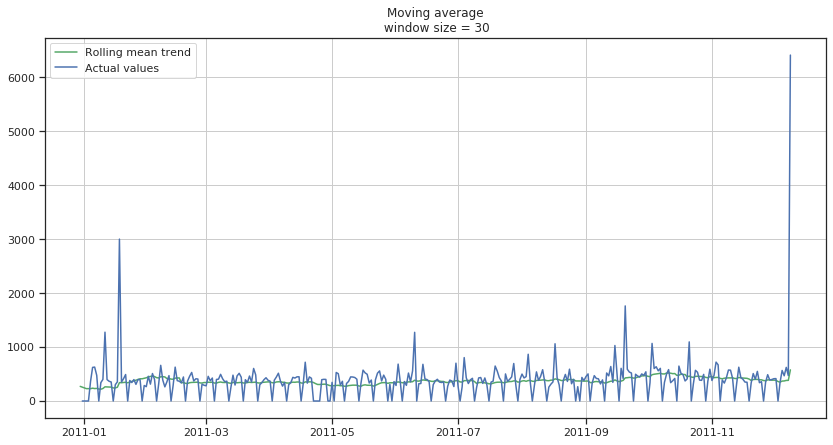

```python
#Smooth by the previous month (30 days)
plot_moving_average(timeSeries, 30)
```

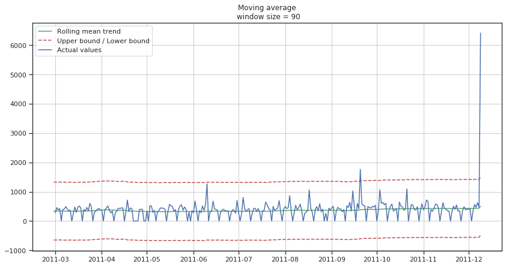

```python
#Smooth by previous quarter (90 days)
plot_moving_average(timeSeries, 90, plot_intervals=True)
```

Les tendances sont plus faciles à repérer maintenant. Remarquez comment la tendance sur 5 jours 30 jours et sur 90 jours montre une courbe montante à la fin. Cela pourrait signifier que la vente devrait monter au cours des prochains jours.

**Lissage exponentiel**

Maintenant, utilisons le lissage exponentiel pour voir s'il peut détecter une meilleure tendance.

```python
def exponential_smoothing(series, alpha):

    result = [series[0]] # first value is same as series
    for n in range(1, len(series)):
        result.append(alpha * series[n] + (1 - alpha) * result[n-1])
    return result
```

```python
def plot_exponential_smoothing(series, alphas):

    plt.figure(figsize=(14, 7))
    for alpha in alphas:
        plt.plot(exponential_smoothing(series, alpha), label="Alpha {}".format(alpha))
    plt.plot(series.values, "c", label = "Actual")
    plt.legend(loc="best")
    plt.axis('tight')
    plt.title("Exponential Smoothing")
    plt.grid(True);
```

Ici, nous utilisons 0,07 et 0,3 comme valeurs pour le facteur de lissage . N'hésitons pas à essayer d'autres valeurs et à voir quel est le résultat.

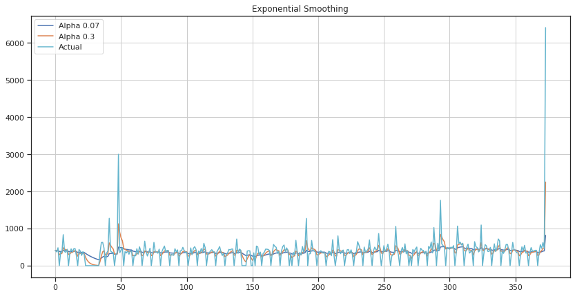

```python
plot_exponential_smoothing(timeSeries, [0.07, 0.3])
```

Comme nous pouvons le voir, une valeur alpha de 0,07 a lissé la courbe tout en captant la plupart des tendances à la hausse et à la baisse.

Maintenant, utilisons le lissage exponentiel double.

```python
def double_exponential_smoothing(series, alpha, beta):

    result = [series[0]]
    for n in range(1, len(series)+1):
        if n == 1:
            level, trend = series[0], series[1] - series[0]
        if n >= len(series): # forecasting
            value = result[-1]
        else:
            value = series[n]
        last_level, level = level, alpha * value + (1 - alpha) * (level + trend)
        trend = beta * (level - last_level) + (1 - beta) * trend
        result.append(level + trend)
    return result
```

```python
def plot_double_exponential_smoothing(series, alphas, betas):

    plt.figure(figsize=(14, 7))
    for alpha in alphas:
        for beta in betas:
            plt.plot(double_exponential_smoothing(series, alpha, beta), label="Alpha {}, beta {}".format(alpha, beta))
    plt.plot(series.values, label = "Actual")
    plt.legend(loc="best")
    plt.axis('tight')
    plt.title("Double Exponential Smoothing")
    plt.grid(True)
```

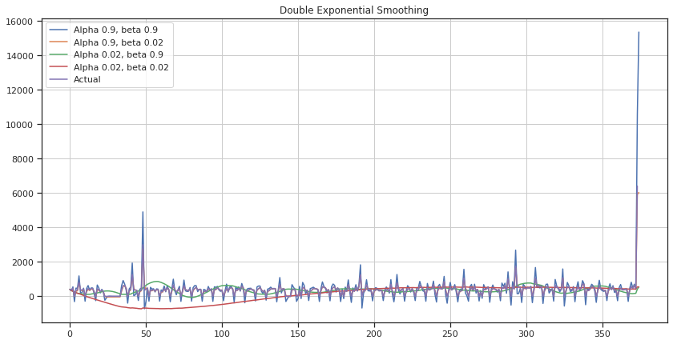

```python
plot_double_exponential_smoothing(timeSeries, alphas=[0.9, 0.02], betas=[0.9, 0.02])
```

### **Modelisation**

Nous devons transformer notre série en un processus stationnaire afin de la modéliser. Par conséquent, appliquons le test Dickey-Fuller pour voir s'il s'agit d'un processus stationnaire:

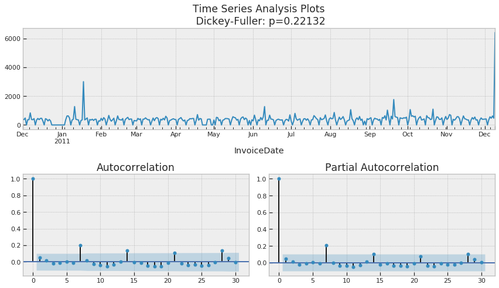

```python
def tsplot(y, lags=None, figsize=(12, 7), syle='bmh'):

    if not isinstance(y, pd.Series):
        y = pd.Series(y)

    with plt.style.context(style='bmh'):
        fig = plt.figure(figsize=figsize)
        layout = (2,2)
        ts_ax = plt.subplot2grid(layout, (0,0), colspan=2)
        acf_ax = plt.subplot2grid(layout, (1,0))
        pacf_ax = plt.subplot2grid(layout, (1,1))

        y.plot(ax=ts_ax)
        p_value = sm.tsa.stattools.adfuller(y)[1]
        ts_ax.set_title('Time Series Analysis Plots\n Dickey-Fuller: p={0:.5f}'.format(p_value))
        smt.graphics.plot_acf(y, lags=lags, ax=acf_ax)
        smt.graphics.plot_pacf(y, lags=lags, ax=pacf_ax)
        plt.tight_layout()

tsplot(timeSeries, lags=30)
```

Selon le test de Dickey-Fuller, la série chronologique est sans surprise non stationnaire.

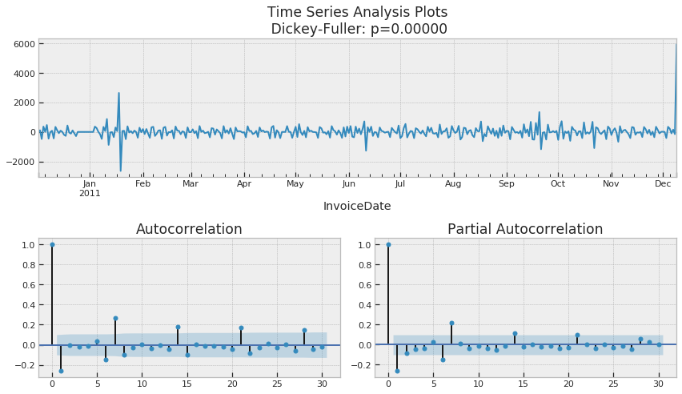

```python
timeSeries_diff = timeSeries - timeSeries.shift(1)
tsplot(timeSeries_diff[1:], lags=30)
```

Notre série est maintenant stationnaire et nous pouvons commencer la modélisation!

## **SARIMA**

Définissons d'abord quelques paramètres et une plage de valeurs pour d'autres paramètres afin de générer une liste de toutes les combinaisons possibles de p, q, d, P, Q, D, s.

```python
#Set initial values and some bounds
ps = range(0, 5)
d = 1
qs = range(0, 5)
Ps = range(0, 5)
D = 1
Qs = range(0, 5)
s = 5

#Create a list with all possible combinations of parameters
parameters = product(ps, qs, Ps, Qs)
parameters_list = list(parameters)
len(parameters_list)
```

```
625
```

Nous avons 625 combinaisons différentes! Nous allons essayer chaque combinaison et former SARIMA avec chacune afin de trouver le modèle le plus performant. Cela peut prendre du temps en fonction de la puissance de traitement de votre ordinateur.

```python
def optimize_SARIMA(parameters_list, d, D, s):
    """
        Return dataframe with parameters and corresponding AIC

        parameters_list - list with (p, q, P, Q) tuples
        d - integration order
        D - seasonal integration order
        s - length of season
    """

    results = []
    best_aic = float('inf')

    for param in tqdm_notebook(parameters_list):
        try: model = sm.tsa.statespace.SARIMAX(timeSeries, order=(param[0], d, param[1]),
                                               seasonal_order=(param[2], D, param[3], s)).fit(disp=-1)
        except:
            continue

        aic = model.aic

        #Save best model, AIC and parameters
        if aic < best_aic:
            best_model = model
            best_aic = aic
            best_param = param
        results.append([param, model.aic])

    result_table = pd.DataFrame(results)
    result_table.columns = ['parameters', 'aic']
    #Sort in ascending order, lower AIC is better
    result_table = result_table.sort_values(by='aic', ascending=True).reset_index(drop=True)

    return result_table

result_table = optimize_SARIMA(parameters_list, d, D, s)
```

**Montage du modèle ARIMA**

```python
#Set parameters that give the lowest AIC (Akaike Information Criteria)

p, q, P, Q = result_table.parameters[0]

best_model = sm.tsa.statespace.SARIMAX(timeSeries, order=(p, d, q),
                                       seasonal_order=(P, D, Q, s)).fit(disp=-1)

print(best_model.summary())
```

```
                                 Statespace Model Results
=========================================================================================
Dep. Variable:                             sales   No. Observations:                  374
Model:             SARIMAX(4, 1, 2)x(0, 1, 2, 5)   Log Likelihood               -2734.467
Date:                           Sat, 22 Feb 2020   AIC                           5486.933
Time:                                   14:19:34   BIC                           5522.106
Sample:                               12-01-2010   HQIC                          5500.907
                                    - 12-09-2011
Covariance Type:                             opg
==============================================================================
                 coef    std err          z      P>|z|      [0.025      0.975]
------------------------------------------------------------------------------
ar.L1         -0.9944      0.264     -3.760      0.000      -1.513      -0.476
ar.L2         -0.4142      0.413     -1.004      0.316      -1.223       0.395
ar.L3         -0.4230      0.362     -1.168      0.243      -1.133       0.287
ar.L4         -0.4823      0.231     -2.087      0.037      -0.935      -0.029
ma.L1          0.2014      0.301      0.669      0.504      -0.389       0.792
ma.L2         -0.4503      0.234     -1.924      0.054      -0.909       0.008
ma.S.L5       -1.4803      0.202     -7.319      0.000      -1.877      -1.084
ma.S.L10       0.5053      0.194      2.605      0.009       0.125       0.885
sigma2      1.596e+05   3968.403     40.214      0.000    1.52e+05    1.67e+05
===================================================================================
Ljung-Box (Q):                       30.69   Jarque-Bera (JB):            269363.27
Prob(Q):                              0.86   Prob(JB):                         0.00
Heteroskedasticity (H):               3.72   Skew:                             9.51
Prob(H) (two-sided):                  0.00   Kurtosis:                       134.17
===================================================================================

Warnings:
[1] Covariance matrix calculated using the outer product of gradients (complex-step).
```

Nous devons toujours exécuter des diagnostics de modèle pour rechercher tout comportement inhabituel.

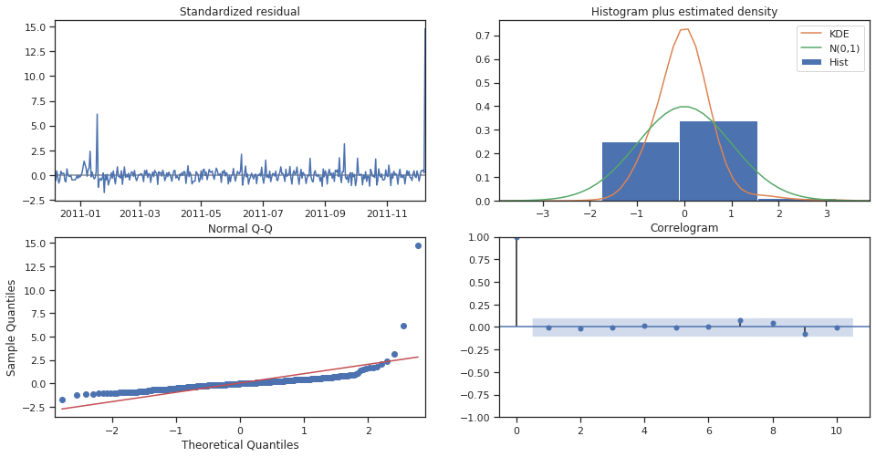

```python
best_model.plot_diagnostics (figsize = (16, 8))
plt.show ()
```

### **Validation des prévisions**

Pour nous aider à comprendre l'exactitude de nos prévisions, nous comparons les ventes prévues aux ventes réelles de la série chronologique et nous fixons des prévisions pour commencer de 2011-11-01 à la fin des données.

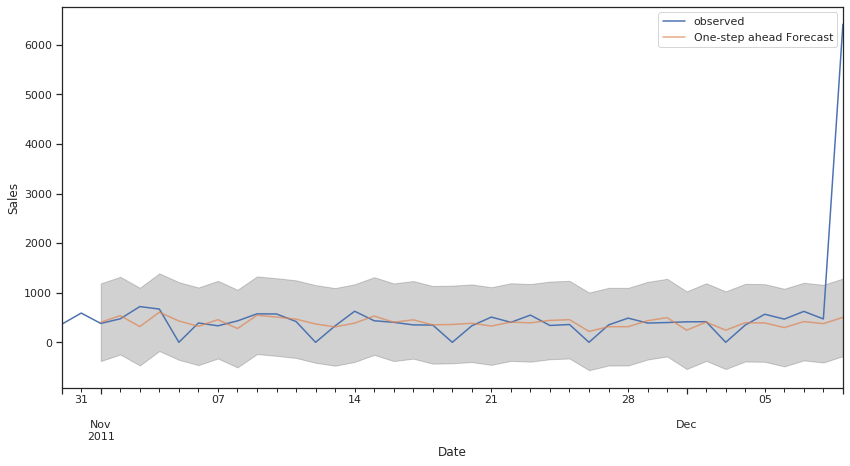

```python
pred = best_model.get_prediction(start=pd.to_datetime('2011-11-01'), dynamic=False)
pred_ci = pred.conf_int()
ax = timeSeries['2011-10-30':].plot(label='observed')
pred.predicted_mean.plot(ax=ax, label='One-step ahead Forecast', alpha=.7, figsize=(14, 7))
ax.fill_between(pred_ci.index,
                pred_ci.iloc[:, 0],
                pred_ci.iloc[:, 1], color='k', alpha=.2)
ax.set_xlabel('Date')
ax.set_ylabel('Sales')
plt.legend()
plt.show()
```

```python
timeSeries_forecasted = pred.predicted_mean
timeSeries_truth = timeSeries['2011-11-01':]
mse = ((timeSeries_forecasted - timeSeries_truth) ** 2).mean()
print('The Mean Squared Error of our forecasts is {}'.format(round(mse, 2)))
```

```
The Mean Squared Error of our forecasts is 924411.78
```

```python
print('The Root Mean Squared Error of our forecasts is {}'.format(round(np.sqrt(mse), 2)))
```

```
The Root Mean Squared Error of our forecasts is 961.46
```

```python
comparison = pd.DataFrame({'actual': timeSeries_truth,
                          'predicted': timeSeries_forecasted},
                          index = pd.date_range(start='2011-11-01', periods=6,))
comparison.head()
```

|  | actual | predicted |
| --- | --- | --- |
| 2011-11-01 | 380.468939 | 405.312883 |
| 2011-11-02 | 473.895672 | 537.512716 |
| 2011-11-03 | 720.736582 | 316.568963 |
| 2011-11-04 | 670.049079 | 607.275842 |
| 2011-11-05 | 0.000000 | 429.971597 |

En statistiques, l' erreur quadratique moyenne (MSE) d'un estimateur mesure la moyenne des carrés des erreurs - c'est-à-dire la différence quadratique moyenne entre les valeurs estimées et ce qui est estimé. Le MSE est une mesure de la qualité d'un estimateur - il est toujours non négatif, et plus le MSE est petit, plus nous sommes proches de trouver la ligne de meilleur ajustement.

L'erreur quadratique moyenne (RMSE) nous indique que notre modèle a été en mesure de prévoir les ventes quotidiennes moyennes dans l'ensemble de test à 961 des ventes réelles. Nos ventes quotidiennes varient d'environ 0 à plus de 6000. À mon avis, c'est un assez bon modèle jusqu'à présent.

### **Production et visualisation des prévisions**

[figure not shown]

```python
pred_uc = best_model.get_forecast(steps=20)
pred_ci = pred_uc.conf_int()
ax = timeSeries['2011-11-25':].plot(label='observed')
pred.predicted_mean.plot(ax=ax, label='Forecast', alpha=.7, figsize=(14, 7))
ax.fill_between(pred_ci.index,
                pred_ci.iloc[:, 0],
                pred_ci.iloc[:, 1], color='k', alpha=.25)
ax.set_xlabel('Date')
ax.set_ylabel('Sales')
plt.legend()
plt.show()
```

```python
print(best_model.predict(start= timeSeries.shape[0], end=timeSeries.shape[0] +20))
print(pred_ci)
```

```
2011-12-10    1593.165293
2011-12-11    1089.732633
2011-12-12    1048.101772
2011-12-13     444.019679
2011-12-14     827.219245
2011-12-15     442.112405
2011-12-16    2171.872461
2011-12-17     722.848252
2011-12-18    1428.166904
2011-12-19     957.758310
2011-12-20     977.187021
2011-12-21    1438.616764
2011-12-22     812.894460
2011-12-23    1465.438281
2011-12-24    1047.893894
2011-12-25    1300.023156
2011-12-26    1133.415758
2011-12-27    1038.931049
2011-12-28    1299.422325
2011-12-29    1205.133617
2011-12-30    1376.373169
Freq: D, dtype: float64
            lower sales  upper sales
2011-12-10   810.183047  2376.147540
2011-12-11   290.154222  1889.311045
2011-12-12   241.964045  1854.239500
2011-12-13  -366.876801  1254.916159
2011-12-14    16.230781  1638.207709
2011-12-15  -369.964431  1254.189241
2011-12-16  1359.790551  2983.954372
2011-12-17  -123.366741  1569.063245
2011-12-18   580.798169  2275.535639
2011-12-19    98.630470  1816.886151
2011-12-20   115.677799  1838.696243
2011-12-21   573.986958  2303.246570
2011-12-22   -62.935189  1688.724109
2011-12-23   587.838133  2343.038429
2011-12-24   158.363737  1937.424051
2011-12-25   407.080048  2192.966264
2011-12-26   233.065796  2033.765721
2011-12-27   133.062068  1944.800030
2011-12-28   389.573911  2209.270739
2011-12-29   287.036469  2123.230764
```

Notre modèle a clairement saisi la saisonnalité des ventes .Lorsque nous prévoyons plus loin dans l'avenir, il est naturel que nous devenions moins confiants dans nos valeurs. Cela se reflète dans les intervalles de confiance générés par notre modèle, qui s'élargissent à mesure que nous avançons vers l'avenir.